# Projet 5 - Segmenter des clients d'un site e-commerce

# Partie 1 : Analyse exploratoire

# Sommaire

## Introduction

### Working environment

Vérification of code compatibility (PEP8)

```python
%load_ext pycodestyle_magic
%pycodestyle_on
# %%flake8  # checking PEP8 compliance
```

Python libraries

```python
%pylab inline
#matplotlib + numpy
#%matplotlib inline
import pandas as pd
import seaborn as sns
```

Displaying parameters

```python
%config IPCompleter.greedy=True #Auto-complétion
pd.options.display.max_colwidth = 90
pd.set_option('display.max_columns', None) # pour afficher toutes les colonnes
pd.set_option('display.max_rows', None)  # Pour afficher toutes les lignes
```

## Data file analyses

### Clients

```python
customers = pd.read_csv('olist_customers_dataset.csv')
```

```python
customers.head()
```

|  | customer_id | customer_unique_id | customer_zip_code_prefix | customer_city | customer_state |
| --- | --- | --- | --- | --- | --- |
| 0 | 06b8999e2fba1a1fbc88172c00ba8bc7 | 861eff4711a542e4b93843c6dd7febb0 | 14409 | franca | SP |
| 1 | 18955e83d337fd6b2def6b18a428ac77 | 290c77bc529b7ac935b93aa66c333dc3 | 9790 | sao bernardo do campo | SP |
| 2 | 4e7b3e00288586ebd08712fdd0374a03 | 060e732b5b29e8181a18229c7b0b2b5e | 1151 | sao paulo | SP |
| 3 | b2b6027bc5c5109e529d4dc6358b12c3 | 259dac757896d24d7702b9acbbff3f3c | 8775 | mogi das cruzes | SP |
| 4 | 4f2d8ab171c80ec8364f7c12e35b23ad | 345ecd01c38d18a9036ed96c73b8d066 | 13056 | campinas | SP |

```python
customers.shape
```

```
(99441, 5)
```

```python
customers.dtypes
```

```
customer_id                 object
customer_unique_id          object
customer_zip_code_prefix     int64
customer_city               object
customer_state              object
dtype: object
```

```python
customers.isna().mean()
```

```
customer_id                 0.0
customer_unique_id          0.0
customer_zip_code_prefix    0.0
customer_city               0.0
customer_state              0.0
dtype: float64
```

```python
customers['customer_city'].unique()
```

```
array(['franca', 'sao bernardo do campo', 'sao paulo', ...,
       'monte bonito', 'sao rafael', 'eugenio de castro'], dtype=object)
```

```python
customers['customer_city'].value_counts()
```

```
sao paulo                           15540
rio de janeiro                       6882
belo horizonte                       2773
brasilia                             2131
curitiba                             1521
campinas                             1444
porto alegre                         1379
salvador                             1245
guarulhos                            1189
sao bernardo do campo                 938
niteroi                               849
santo andre                           797
osasco                                746
santos                                713
goiania                               692
sao jose dos campos                   691
fortaleza                             654
sorocaba                              633
recife                                613
florianopolis                         570
jundiai                               565
ribeirao preto                        510
belem                                 447
nova iguacu                           442
barueri                               433
juiz de fora                          427
contagem                              426
sao goncalo                           409
mogi das cruzes                       383
vitoria                               380
uberlandia                            374
piracicaba                            369
sao luis                              353
sao jose do rio preto                 335
vila velha                            334
carapicuiba                           328
maua                                  323
campo grande                          320
praia grande                          316
londrina                              306
```

[output cut: 4065 more lines]

```
vila bela da santissima trindade        1
senhora dos remedios                    1
nova boa vista                          1
inocencia                               1
machadinho                              1
divino das laranjeiras                  1
galia                                   1
lagoa de sao francisco                  1
uniao da serra                          1
bequimao                                1
andarai                                 1
vargem grande                           1
curvelandia                             1
eugenio de castro                       1
Name: customer_city, dtype: int64
```

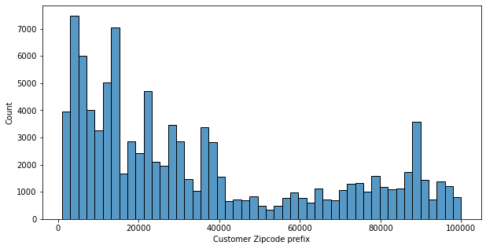

```python
plt.figure(figsize=(10, 5))
sns.histplot(customers['customer_zip_code_prefix'])
plt.xlabel('Customer Zipcode prefix')
plt.show()
```

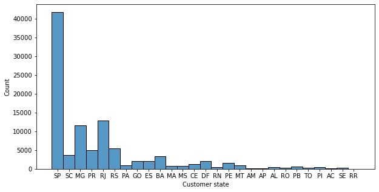

```python
plt.figure(figsize=(10, 5))
sns.histplot(customers['customer_state'])
plt.xlabel('Customer state')
plt.show()
```

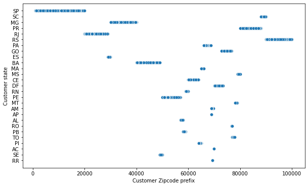

```python
plt.figure(figsize=(10, 6))
sns.scatterplot(data=customers,
                x='customer_zip_code_prefix',
                y='customer_state')
plt.xlabel('Customer Zipcode prefix')
plt.ylabel('Customer state')
plt.show()
```

### Geolocation

```python
geolocation = pd.read_csv('olist_geolocation_dataset.csv')
```

```python
geolocation.head()
```

|  | geolocation_zip_code_prefix | geolocation_lat | geolocation_lng | geolocation_city | geolocation_state |
| --- | --- | --- | --- | --- | --- |
| 0 | 1037 | -23.545621 | -46.639292 | sao paulo | SP |
| 1 | 1046 | -23.546081 | -46.644820 | sao paulo | SP |
| 2 | 1046 | -23.546129 | -46.642951 | sao paulo | SP |
| 3 | 1041 | -23.544392 | -46.639499 | sao paulo | SP |
| 4 | 1035 | -23.541578 | -46.641607 | sao paulo | SP |

```python
geolocation.shape
```

```
(1000163, 5)
```

```python
geolocation.dtypes
```

```
geolocation_zip_code_prefix      int64
geolocation_lat                float64
geolocation_lng                float64
geolocation_city                object
geolocation_state               object
dtype: object
```

```python
geolocation.isna().mean()
```

```
geolocation_zip_code_prefix    0.0
geolocation_lat                0.0
geolocation_lng                0.0
geolocation_city               0.0
geolocation_state              0.0
dtype: float64
```

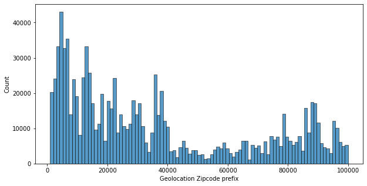

```python
plt.figure(figsize=(10, 5))
sns.histplot(geolocation['geolocation_zip_code_prefix'])
plt.xlabel('Geolocation Zipcode prefix')
plt.show()
```

```python
geolocation['geolocation_city'].value_counts()
```

```
sao paulo                                 135800
rio de janeiro                             62151
belo horizonte                             27805
são paulo                                  24918
curitiba                                   16593
porto alegre                               13521
salvador                                   11865
guarulhos                                  11340
brasilia                                   10470
sao bernardo do campo                       8112
osasco                                      7658
santo andre                                 6863
niteroi                                     6534
recife                                      6168
goiania                                     5661
fortaleza                                   5538
campinas                                    5479
sorocaba                                    5361
santos                                      5000
barueri                                     4971
juiz de fora                                4679
contagem                                    4395
campo grande                                4332
ribeirao preto                              4187
florianopolis                               4148
nova iguacu                                 4022
mogi das cruzes                             3913
belem                                       3789
sao jose dos campos                         3759
sao goncalo                                 3601
uberlandia                                  3520
vitoria                                     3478
duque de caxias                             3444
bauru                                       3270
sao jose do rio preto                       3190
londrina                                    3144
carapicuiba                                 3041
diadema                                     2986
praia grande                                2952
joinville                                   2922
```

[output cut: 7957 more lines]

```
casserengue                                    1
piloezinhos                                    1
curral de cima                                 1
damião                                         1
sossego                                        1
são miguel dos milagres                        1
azambuja                                       1
barra de  santo antônio                        1
barra de santo antônio                         1
jacuípe                                        1
mar vermelho                                   1
quebrangulo                                    1
poço das trincheiras                           1
poxim                                          1
Name: geolocation_city, dtype: int64
```

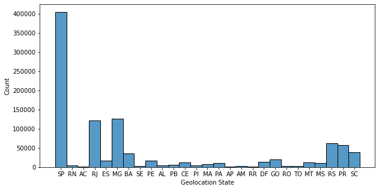

```python
plt.figure(figsize=(10, 5))
sns.histplot(geolocation['geolocation_state'])
plt.xlabel('Geolocation State')
plt.show()
```

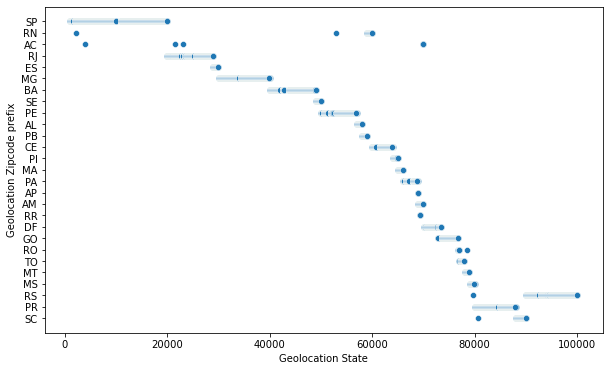

```python
plt.figure(figsize=(10, 6))
sns.scatterplot(data=geolocation,
                x='geolocation_zip_code_prefix',
                y='geolocation_state')
plt.xlabel('Geolocation State')
plt.ylabel('Geolocation Zipcode prefix')
plt.show()
```

#### Résumé du fichier : *geolocation*

- Contient 1000163 individus et 5 variables :
1. geolocation_zip_code_prefix (num.): code postal de la commande
2. geolocation_lat (num.) : lattitude
3. geolocation_lng (num.) : longitude
4. geolocation_city (cat.): ville de la commande
5. geolocation_state (cat.) : état ou lieu de la commande
- Aucune donnée manquante (remplissage 100%)

**Ce fichier contient des informations permettant de géolocaliser sur une carte les villes et région avec leurs coordonnées GPS**

### Orders

```python
orders = pd.read_csv('olist_orders_dataset.csv')
```

```python
orders.head()
```

|  | order_id | customer_id | order_status | order_purchase_timestamp | order_approved_at | order_delivered_carrier_date | order_delivered_customer_date | order_estimated_delivery_date |
| --- | --- | --- | --- | --- | --- | --- | --- | --- |
| 0 | e481f51cbdc54678b7cc49136f2d6af7 | 9ef432eb6251297304e76186b10a928d | delivered | 2017-10-02 10:56:33 | 2017-10-02 11:07:15 | 2017-10-04 19:55:00 | 2017-10-10 21:25:13 | 2017-10-18 00:00:00 |
| 1 | 53cdb2fc8bc7dce0b6741e2150273451 | b0830fb4747a6c6d20dea0b8c802d7ef | delivered | 2018-07-24 20:41:37 | 2018-07-26 03:24:27 | 2018-07-26 14:31:00 | 2018-08-07 15:27:45 | 2018-08-13 00:00:00 |
| 2 | 47770eb9100c2d0c44946d9cf07ec65d | 41ce2a54c0b03bf3443c3d931a367089 | delivered | 2018-08-08 08:38:49 | 2018-08-08 08:55:23 | 2018-08-08 13:50:00 | 2018-08-17 18:06:29 | 2018-09-04 00:00:00 |
| 3 | 949d5b44dbf5de918fe9c16f97b45f8a | f88197465ea7920adcdbec7375364d82 | delivered | 2017-11-18 19:28:06 | 2017-11-18 19:45:59 | 2017-11-22 13:39:59 | 2017-12-02 00:28:42 | 2017-12-15 00:00:00 |
| 4 | ad21c59c0840e6cb83a9ceb5573f8159 | 8ab97904e6daea8866dbdbc4fb7aad2c | delivered | 2018-02-13 21:18:39 | 2018-02-13 22:20:29 | 2018-02-14 19:46:34 | 2018-02-16 18:17:02 | 2018-02-26 00:00:00 |

```python
orders.shape
```

```
(99441, 8)
```

```python
orders.dtypes
```

```
order_id                         object
customer_id                      object
order_status                     object
order_purchase_timestamp         object
order_approved_at                object
order_delivered_carrier_date     object
order_delivered_customer_date    object
order_estimated_delivery_date    object
dtype: object
```

```python
orders.isna().mean()
```

```
order_id                         0.000000
customer_id                      0.000000
order_status                     0.000000
order_purchase_timestamp         0.000000
order_approved_at                0.001609
order_delivered_carrier_date     0.017930
order_delivered_customer_date    0.029817
order_estimated_delivery_date    0.000000
dtype: float64
```

```python
orders['order_status'].value_counts()
```

```
delivered      96478
shipped         1107
canceled         625
unavailable      609
invoiced         314
processing       301
created            5
approved           2
Name: order_status, dtype: int64
```

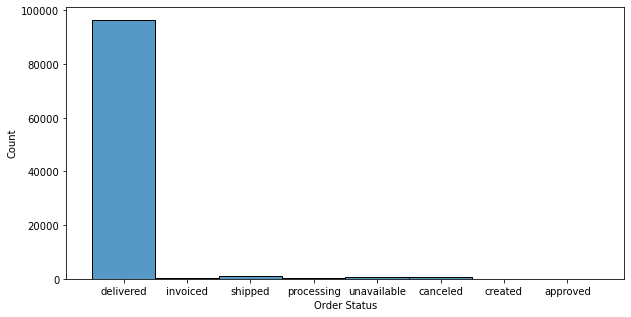

```python
plt.figure(figsize=(10, 5))
sns.histplot(orders['order_status'])
plt.xlabel('Order Status')
plt.show()
```

#### Résumé du fichier : *orders*

- Contient 99441 individus et 8 variables **catégorielles** :
1. order_id : identifiant de la commande
2. customer_id : identifiant du client
3. order_status : statut de la commande
4. order_purchase_timestamp : date et heure d'achat
5. order_approved_at : date et heure de vérification et validation de la commande
6. order_delivered_carrier_date : date de remise de la commande au transporteur
7. order_delivered_customer_date : date de réception de la commande par le client
8. order_estimated_delivery_date : date de livraison estimée
- Quelques données manquantes pour les variables order_approved_at, order_delivered_carrier_date, order_delivered_customer_date
- Remplissage 100% pour les variables order_id, customer_id, order_status, order_purchase_timestamp, order_estimated_delivery_date

```python
# Only delivered status will be considered
orders = orders[(orders['order_status'] == 'delivered')]
```

### Items

```python
items = pd.read_csv('olist_order_items_dataset.csv')
```

```python
items.head()
```

|  | order_id | order_item_id | product_id | seller_id | shipping_limit_date | price | freight_value |
| --- | --- | --- | --- | --- | --- | --- | --- |
| 0 | 00010242fe8c5a6d1ba2dd792cb16214 | 1 | 4244733e06e7ecb4970a6e2683c13e61 | 48436dade18ac8b2bce089ec2a041202 | 2017-09-19 09:45:35 | 58.90 | 13.29 |
| 1 | 00018f77f2f0320c557190d7a144bdd3 | 1 | e5f2d52b802189ee658865ca93d83a8f | dd7ddc04e1b6c2c614352b383efe2d36 | 2017-05-03 11:05:13 | 239.90 | 19.93 |
| 2 | 000229ec398224ef6ca0657da4fc703e | 1 | c777355d18b72b67abbeef9df44fd0fd | 5b51032eddd242adc84c38acab88f23d | 2018-01-18 14:48:30 | 199.00 | 17.87 |
| 3 | 00024acbcdf0a6daa1e931b038114c75 | 1 | 7634da152a4610f1595efa32f14722fc | 9d7a1d34a5052409006425275ba1c2b4 | 2018-08-15 10:10:18 | 12.99 | 12.79 |
| 4 | 00042b26cf59d7ce69dfabb4e55b4fd9 | 1 | ac6c3623068f30de03045865e4e10089 | df560393f3a51e74553ab94004ba5c87 | 2017-02-13 13:57:51 | 199.90 | 18.14 |

```python
items.shape
```

```
(112650, 7)
```

```python
items.dtypes
```

```
order_id                object
order_item_id            int64
product_id              object
seller_id               object
shipping_limit_date     object
price                  float64
freight_value          float64
dtype: object
```

```python
items.isna().mean()
```

```
order_id               0.0
order_item_id          0.0
product_id             0.0
seller_id              0.0
shipping_limit_date    0.0
price                  0.0
freight_value          0.0
dtype: float64
```

```python
items['order_item_id'].value_counts()
```

```
1     98666
2      9803
3      2287
4       965
5       460
6       256
7        58
8        36
9        28
10       25
11       17
12       13
13        8
14        7
15        5
16        3
17        3
18        3
19        3
20        3
21        1
Name: order_item_id, dtype: int64
```

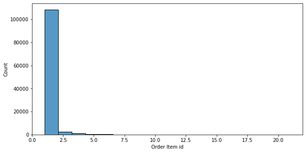

```python
plt.figure(figsize=(10, 5))
sns.histplot(items['order_item_id'])
plt.xlabel('Order Item id')
plt.show()
```

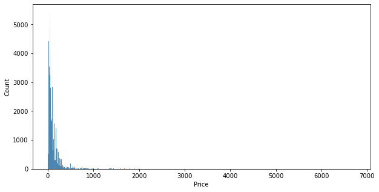

```python
plt.figure(figsize=(10, 5))
sns.histplot(items['price'])
plt.xlabel('Price')
plt.show()
```

```python
items['price'].describe()
```

```
count    112650.000000
mean        120.653739
std         183.633928
min           0.850000
25%          39.900000
50%          74.990000
75%         134.900000
max        6735.000000
Name: price, dtype: float64
```

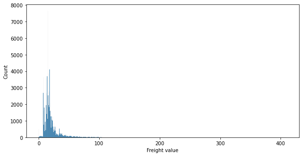

```python
plt.figure(figsize=(10, 5))
sns.histplot(items['freight_value'])
plt.xlabel('Freight value')
plt.show()
```

```python
items['freight_value'].describe()
```

```
count    112650.000000
mean         19.990320
std          15.806405
min           0.000000
25%          13.080000
50%          16.260000
75%          21.150000
max         409.680000
Name: freight_value, dtype: float64
```

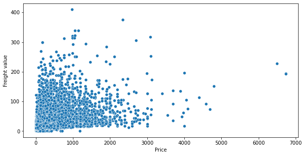

```python
plt.figure(figsize=(10, 5))
sns.scatterplot(data=items, x='price', y='freight_value')
plt.xlabel('Price')
plt.ylabel('Freight value')
plt.show()
```

#### Résumé du fichier : *items*

- Contient 112650 individus et 7 variables :
1. order_id (cat.) : identifiant de la commande
2. order_item_id (num.) : identifiant de l'objet dans la commande ou du nombre d'objets ?
3. product_id (cat.) : identifiant du produit
4. seller_id (cat.) : identifiant du vendeur
5. shipping_limit_date (cat.): date maxi d'envoi
6. price (num.) : prix
7. freight_value (num.) : prix des frais de port
- Aucune donnée manquante (remplissage 100%)
- Présence d'outliers pour les variables *price* et _freight*value*
- Pas de relation linéaire entre *price* et _freight*value*

### Products

```python
products = pd.read_csv('olist_products_dataset.csv')
```

```python
products.head()
```

|  | product_id | product_category_name | product_name_lenght | product_description_lenght | product_photos_qty | product_weight_g | product_length_cm | product_height_cm | product_width_cm |
| --- | --- | --- | --- | --- | --- | --- | --- | --- | --- |
| 0 | 1e9e8ef04dbcff4541ed26657ea517e5 | perfumaria | 40.0 | 287.0 | 1.0 | 225.0 | 16.0 | 10.0 | 14.0 |
| 1 | 3aa071139cb16b67ca9e5dea641aaa2f | artes | 44.0 | 276.0 | 1.0 | 1000.0 | 30.0 | 18.0 | 20.0 |
| 2 | 96bd76ec8810374ed1b65e291975717f | esporte_lazer | 46.0 | 250.0 | 1.0 | 154.0 | 18.0 | 9.0 | 15.0 |
| 3 | cef67bcfe19066a932b7673e239eb23d | bebes | 27.0 | 261.0 | 1.0 | 371.0 | 26.0 | 4.0 | 26.0 |
| 4 | 9dc1a7de274444849c219cff195d0b71 | utilidades_domesticas | 37.0 | 402.0 | 4.0 | 625.0 | 20.0 | 17.0 | 13.0 |

#### Traduction portugais -> angalis des catégories de produits

```python
translation = pd.read_csv('product_category_name_translation.csv')
translation.head()
```

|  | product_category_name | product_category_name_english |
| --- | --- | --- |
| 0 | beleza_saude | health_beauty |
| 1 | informatica_acessorios | computers_accessories |
| 2 | automotivo | auto |
| 3 | cama_mesa_banho | bed_bath_table |
| 4 | moveis_decoracao | furniture_decor |

```python
# Fusion des deux dataframes
products = pd.merge(products, translation,
                    on='product_category_name', how='inner')
# Modification de l'index de la colonne product_category_name_english
products = products.iloc[:, [0, 1, 9, 2, 3, 4, 5, 6, 7, 8]]
# Elimination de la colonne en portugais
# products = products.drop('product_category_name', axis=1)
# Affichage des 5 premières lignes
products.head()
```

|  | product_id | product_category_name | product_category_name_english | product_name_lenght | product_description_lenght | product_photos_qty | product_weight_g | product_length_cm | product_height_cm | product_width_cm |
| --- | --- | --- | --- | --- | --- | --- | --- | --- | --- | --- |
| 0 | 1e9e8ef04dbcff4541ed26657ea517e5 | perfumaria | perfumery | 40.0 | 287.0 | 1.0 | 225.0 | 16.0 | 10.0 | 14.0 |
| 1 | 6a2fb4dd53d2cdb88e0432f1284a004c | perfumaria | perfumery | 39.0 | 346.0 | 2.0 | 400.0 | 27.0 | 5.0 | 20.0 |
| 2 | 0d009643171aee696f4733340bc2fdd0 | perfumaria | perfumery | 52.0 | 150.0 | 1.0 | 422.0 | 21.0 | 16.0 | 18.0 |
| 3 | b1eae565a61935e0011ee7682fef9dc9 | perfumaria | perfumery | 49.0 | 460.0 | 2.0 | 267.0 | 17.0 | 13.0 | 17.0 |
| 4 | 8da90b37f0fb171b4877c124f965b1f6 | perfumaria | perfumery | 56.0 | 733.0 | 3.0 | 377.0 | 18.0 | 13.0 | 15.0 |

```python
products.shape
```

```
(32328, 10)
```

```python
products.dtypes
```

```
product_id                        object
product_category_name             object
product_category_name_english     object
product_name_lenght              float64
product_description_lenght       float64
product_photos_qty               float64
product_weight_g                 float64
product_length_cm                float64
product_height_cm                float64
product_width_cm                 float64
dtype: object
```

```python
products.isna().mean()
```

```
product_id                       0.000000
product_category_name            0.000000
product_category_name_english    0.000000
product_name_lenght              0.000000
product_description_lenght       0.000000
product_photos_qty               0.000000
product_weight_g                 0.000031
product_length_cm                0.000031
product_height_cm                0.000031
product_width_cm                 0.000031
dtype: float64
```

#### product_name_lenght

```python
products['product_name_lenght'].describe()
```

```
count    32328.000000
mean        48.474078
std         10.246388
min          5.000000
25%         42.000000
50%         51.000000
75%         57.000000
max         76.000000
Name: product_name_lenght, dtype: float64
```

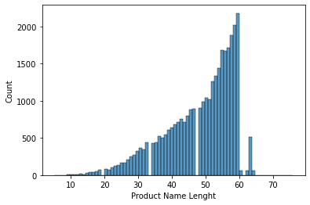

```python
plt.figure()
sns.histplot(products['product_name_lenght'])
plt.xlabel('Product Name Lenght')
plt.show()
```

#### product_description_lenght

```python
products['product_description_lenght'].describe()
```

```
count    32328.000000
mean       771.520168
std        635.180062
min          4.000000
25%        339.000000
50%        595.000000
75%        972.000000
max       3992.000000
Name: product_description_lenght, dtype: float64
```

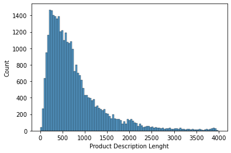

```python
plt.figure()
sns.histplot(products['product_description_lenght'])
plt.xlabel('Product Description Lenght')
plt.show()
```

#### product_photos_qty

```python
products['product_photos_qty'].describe()
```

```
count    32328.000000
mean         2.188815
std          1.736746
min          1.000000
25%          1.000000
50%          1.000000
75%          3.000000
max         20.000000
Name: product_photos_qty, dtype: float64
```

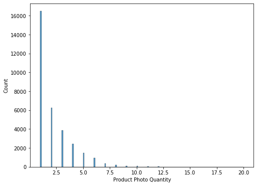

```python
plt.figure(figsize=(8, 6))
sns.histplot(products['product_photos_qty'])
plt.xlabel('Product Photo Quantity')
plt.show()
```

#### product_weight_g

```python
products['product_weight_g'].describe()
```

```
count    32327.000000
mean      2276.960807
std       4279.734063
min          0.000000
25%        300.000000
50%        700.000000
75%       1900.000000
max      40425.000000
Name: product_weight_g, dtype: float64
```

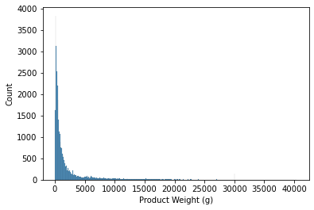

```python
plt.figure()
sns.histplot(products['product_weight_g'])
plt.xlabel('Product Weight (g)')
plt.show()
```

#### product_length_cm

```python
products['product_length_cm'].describe()
```

```
count    32327.000000
mean        30.856498
std         16.958460
min          7.000000
25%         18.000000
50%         25.000000
75%         38.000000
max        105.000000
Name: product_length_cm, dtype: float64
```

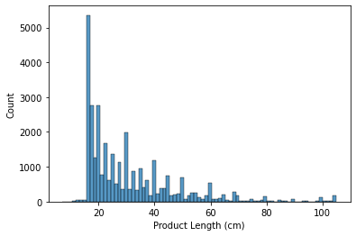

```python
plt.figure()
sns.histplot(products['product_length_cm'])
plt.xlabel('Product Length (cm)')
plt.show()
```

#### product_height_cm

```python
products['product_height_cm'].describe()
```

```
count    32327.000000
mean        16.955950
std         13.637246
min          2.000000
25%          8.000000
50%         13.000000
75%         20.500000
max        105.000000
Name: product_height_cm, dtype: float64
```

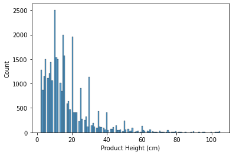

```python
plt.figure()
sns.histplot(products['product_height_cm'])
plt.xlabel('Product Height (cm)')
plt.show()
```

#### product_width_cm

```python
products['product_width_cm'].describe()
```

```
count    32327.000000
mean        23.208464
std         12.080665
min          6.000000
25%         15.000000
50%         20.000000
75%         30.000000
max        118.000000
Name: product_width_cm, dtype: float64
```

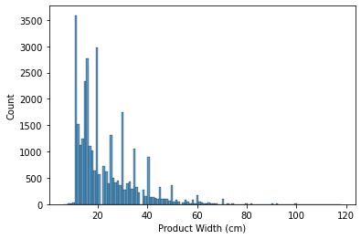

```python
plt.figure()
sns.histplot(products['product_width_cm'])
plt.xlabel('Product Width (cm)')
plt.show()
```

#### 2-features analyses

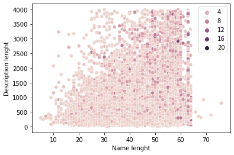

```python
plt.figure()
sns.scatterplot(data=products,
                hue='product_photos_qty',
                x='product_name_lenght',
                y='product_description_lenght')
plt.xlabel('Name lenght')
plt.ylabel('Description lenght')
plt.legend(loc='best')
plt.show()
```

#### Résumé du fichier : *products*

- Contient 32328 individus et 10 variables :
1. product_id (cat.) : identifiant du produit
2. product_category_name (cat.) : catégorie du produit (en portugais)
3. product_category_name_english (cat.) : catégorie du produit (en anglais)
4. product_name_lenght (num.) : longueur du nom du produit
5. product_description_lenght (num.) : longueur de la description du produit
6. product_photos_qty (num.) : nombre de photos du produit
7. product_weight_g (num.) : poids en g. du produit
8. product_length_cm (num.) : longueur en cm du produit
9. product_height_cm (num.) : hauteur en cm du produit
10. product_width_cm (num.) : largeur en cm du produit
- Aucune donnée manquante (remplissage 100%) SAUF pour les variables _product_weight*g*, _product_length*cm*, _product_height*cm*, _product_width*cm* : même taux de remplissage, on suspecte que les données manquantes concernent les mêmes individus

### Payments

```python
payments = pd.read_csv('olist_order_payments_dataset.csv')
```

```python
payments.head()
```

|  | order_id | payment_sequential | payment_type | payment_installments | payment_value |
| --- | --- | --- | --- | --- | --- |
| 0 | b81ef226f3fe1789b1e8b2acac839d17 | 1 | credit_card | 8 | 99.33 |
| 1 | a9810da82917af2d9aefd1278f1dcfa0 | 1 | credit_card | 1 | 24.39 |
| 2 | 25e8ea4e93396b6fa0d3dd708e76c1bd | 1 | credit_card | 1 | 65.71 |
| 3 | ba78997921bbcdc1373bb41e913ab953 | 1 | credit_card | 8 | 107.78 |
| 4 | 42fdf880ba16b47b59251dd489d4441a | 1 | credit_card | 2 | 128.45 |

```python
payments.shape
```

```
(103886, 5)
```

```python
payments.dtypes
```

```
order_id                 object
payment_sequential        int64
payment_type             object
payment_installments      int64
payment_value           float64
dtype: object
```

```python
payments.isna().mean()
```

```
order_id                0.0
payment_sequential      0.0
payment_type            0.0
payment_installments    0.0
payment_value           0.0
dtype: float64
```

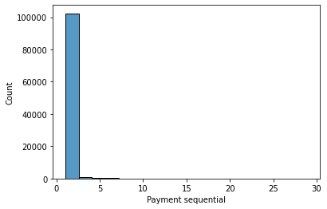

```python
plt.figure()
sns.histplot(payments['payment_sequential'])
plt.xlabel('Payment sequential')
plt.show()
```

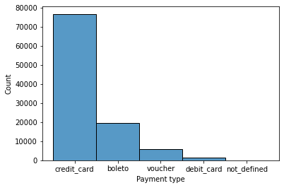

```python
plt.figure()
sns.histplot(payments['payment_type'])
plt.xlabel('Payment type')
plt.show()
```

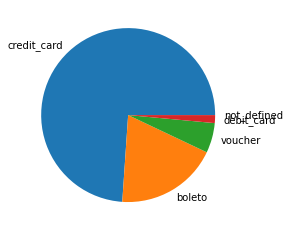

```python
plt.figure()
plt.pie(payments['payment_type'].value_counts(),
        labels=payments['payment_type'].unique())
plt.show()
```

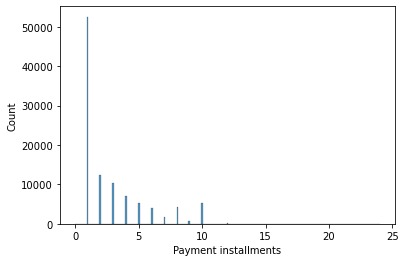

```python
plt.figure()
sns.histplot(payments['payment_installments'])
plt.xlabel('Payment installments')
plt.show()
```

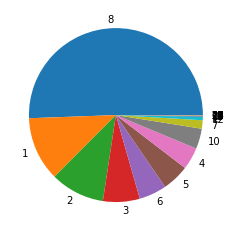

```python
plt.figure()
plt.pie(payments['payment_installments'].value_counts(),
        labels=payments['payment_installments'].unique())
plt.show()
```

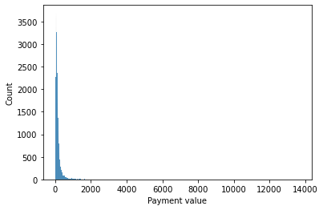

```python
plt.figure()
sns.histplot(payments['payment_value'])
plt.xlabel('Payment value')
plt.show()
```

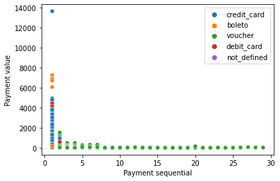

```python
plt.figure()
sns.scatterplot(data=payments,
                x='payment_sequential',
                y='payment_value',
                hue='payment_type')
plt.xlabel('Payment sequential')
plt.ylabel('Payment value')
plt.legend(loc='best')
plt.show()
```

#### Résumé du fichier : *payments*

- Contient 103886 individus et 5 variables :
1. order_id (cat.) : identifiants de la commande
2. payment_sequential (num.) : nombre de moyens de paiement utilisés pour payer la commande
3. payment_type (cat.) : type de moyens de paiement utisliés
4. payment_installments (num.) : nombre de tronçons de paiement du montant total de la commande
5. payment_value (num.) : Montant total payé
- Aucune donnée manquante (remplissage 100%)

### Reviews

```python
reviews = pd.read_csv('olist_order_reviews_dataset.csv')
```

```python
reviews.head()
```

|  | review_id | order_id | review_score | review_comment_title | review_comment_message | review_creation_date | review_answer_timestamp |
| --- | --- | --- | --- | --- | --- | --- | --- |
| 0 | 7bc2406110b926393aa56f80a40eba40 | 73fc7af87114b39712e6da79b0a377eb | 4 | NaN | NaN | 2018-01-18 00:00:00 | 2018-01-18 21:46:59 |
| 1 | 80e641a11e56f04c1ad469d5645fdfde | a548910a1c6147796b98fdf73dbeba33 | 5 | NaN | NaN | 2018-03-10 00:00:00 | 2018-03-11 03:05:13 |
| 2 | 228ce5500dc1d8e020d8d1322874b6f0 | f9e4b658b201a9f2ecdecbb34bed034b | 5 | NaN | NaN | 2018-02-17 00:00:00 | 2018-02-18 14:36:24 |
| 3 | e64fb393e7b32834bb789ff8bb30750e | 658677c97b385a9be170737859d3511b | 5 | NaN | Recebi bem antes do prazo estipulado. | 2017-04-21 00:00:00 | 2017-04-21 22:02:06 |
| 4 | f7c4243c7fe1938f181bec41a392bdeb | 8e6bfb81e283fa7e4f11123a3fb894f1 | 5 | NaN | Parabéns lojas lannister adorei comprar pela Internet seguro e prático Parabéns a todo... | 2018-03-01 00:00:00 | 2018-03-02 10:26:53 |

```python
reviews.shape
```

```
(99224, 7)
```

```python
reviews.dtypes
```

```
review_id                  object
order_id                   object
review_score                int64
review_comment_title       object
review_comment_message     object
review_creation_date       object
review_answer_timestamp    object
dtype: object
```

```python
reviews.isna().mean()
```

```
review_id                  0.000000
order_id                   0.000000
review_score               0.000000
review_comment_title       0.883415
review_comment_message     0.587025
review_creation_date       0.000000
review_answer_timestamp    0.000000
dtype: float64
```

[output not shown]

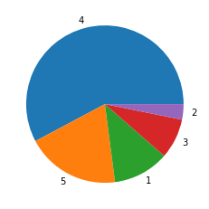

```python
plt.pie(reviews['review_score'].value_counts(),
        labels=reviews['review_score'].unique())
```

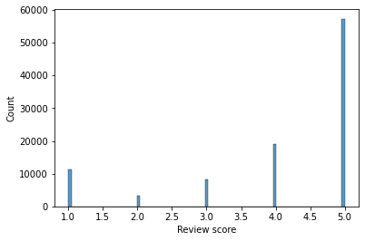

```python
plt.figure()
sns.histplot(reviews['review_score'])
plt.xlabel('Review score')
plt.show()
```

#### Résumé du fichier : *reviews*

- Contient 99224 individus et 7 variables :
1. review_id (cat.) : identifiant de l'avis
2. order_id (cat.) : identifiants de la commande
3. review_score (num.) : note laissée avec l'avis (sur 5)
4. review_comment_title (cat.) : titre de l'avis
5. review_comment_message (cat.) : texte de l'avis
6. review_creation_date (cat.) : date d'ajout de l'avis
7. review_answer_timestamp (cat.) : heure de réponse à l'avis (?)
- Aucune donnée manquante (remplissage 100%) SAUF pour les variables _review_comment*title* & _review_comment*message* (on peut laisser une note sans message)
- La majorité des notes sont supérieures à la moyenne

### Sellers

```python
sellers = pd.read_csv('olist_sellers_dataset.csv')
```

```python
sellers.head()
```

|  | seller_id | seller_zip_code_prefix | seller_city | seller_state |
| --- | --- | --- | --- | --- |
| 0 | 3442f8959a84dea7ee197c632cb2df15 | 13023 | campinas | SP |
| 1 | d1b65fc7debc3361ea86b5f14c68d2e2 | 13844 | mogi guacu | SP |
| 2 | ce3ad9de960102d0677a81f5d0bb7b2d | 20031 | rio de janeiro | RJ |
| 3 | c0f3eea2e14555b6faeea3dd58c1b1c3 | 4195 | sao paulo | SP |
| 4 | 51a04a8a6bdcb23deccc82b0b80742cf | 12914 | braganca paulista | SP |

```python
sellers.shape
```

```
(3095, 4)
```

```python
sellers.dtypes
```

```
seller_id                 object
seller_zip_code_prefix     int64
seller_city               object
seller_state              object
dtype: object
```

```python
sellers.isna().mean()
```

```
seller_id                 0.0
seller_zip_code_prefix    0.0
seller_city               0.0
seller_state              0.0
dtype: float64
```

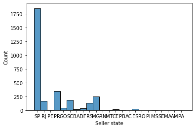

```python
plt.figure()
sns.histplot(data=sellers, x='seller_state')
plt.xlabel('Seller state')
plt.show()
```

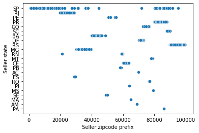

```python
plt.figure()
sns.scatterplot(data=sellers, x='seller_zip_code_prefix', y='seller_state')
plt.xlabel('Seller zipcode prefix')
plt.ylabel('Seller state')
plt.show()
```

#### Résumé du fichier : *sellers*

- Contient 3095 individus et 4 variables :
1. seller_id (cat.) : identifiant du vendeur
2. seller_zip_code_prefix (num.) : code postal du vendeur (préfixe)
3. seller_city (cat.) : ville du vendeur
4. seller_state (cat.) : état/région du vendeur
- Aucune donnée manquante (remplissage 100%)
- La majorité des vendeurs sont dans la région de Sao Paulo

## Creation of the global dataset

### Files to merge

Identification of useful features for join/merge:

- customers --> 'customer_id'
- orders --> 'order_id', 'customer_id'
- products --> 'product_id'
- items --> 'order_id', 'order_item_id', 'product_id', 'seller_id'
- payments --> 'order_id'
- reviews --> ''

No use of *geolocation* & *sellers* (clustering focusing on clients)

### Customers + orders: building *Frequency* feature

```python
df = pd.merge(customers, orders, on='customer_id', how='inner')
```

```python
# Counting the number of orders per unique customer
total_number_of_orders = pd.DataFrame(df.groupby('customer_unique_id')['order_id'].count())

# Rename the column in 'total_number_of_orders'
total_number_of_orders.columns = ['total_number_of_orders']

# Merging with dataframe
df = pd.merge(df, total_number_of_orders, on='customer_unique_id', how='inner')
```

```
2:80: E501 line too long (91 > 79 characters)
```

```python
df.head()
```

|  | customer_id | customer_unique_id | customer_zip_code_prefix | customer_city | customer_state | order_id | order_status | order_purchase_timestamp | order_approved_at | order_delivered_carrier_date | order_delivered_customer_date | order_estimated_delivery_date | total_number_of_orders |
| --- | --- | --- | --- | --- | --- | --- | --- | --- | --- | --- | --- | --- | --- |
| 0 | 06b8999e2fba1a1fbc88172c00ba8bc7 | 861eff4711a542e4b93843c6dd7febb0 | 14409 | franca | SP | 00e7ee1b050b8499577073aeb2a297a1 | delivered | 2017-05-16 15:05:35 | 2017-05-16 15:22:12 | 2017-05-23 10:47:57 | 2017-05-25 10:35:35 | 2017-06-05 00:00:00 | 1 |
| 1 | 18955e83d337fd6b2def6b18a428ac77 | 290c77bc529b7ac935b93aa66c333dc3 | 9790 | sao bernardo do campo | SP | 29150127e6685892b6eab3eec79f59c7 | delivered | 2018-01-12 20:48:24 | 2018-01-12 20:58:32 | 2018-01-15 17:14:59 | 2018-01-29 12:41:19 | 2018-02-06 00:00:00 | 1 |
| 2 | 4e7b3e00288586ebd08712fdd0374a03 | 060e732b5b29e8181a18229c7b0b2b5e | 1151 | sao paulo | SP | b2059ed67ce144a36e2aa97d2c9e9ad2 | delivered | 2018-05-19 16:07:45 | 2018-05-20 16:19:10 | 2018-06-11 14:31:00 | 2018-06-14 17:58:51 | 2018-06-13 00:00:00 | 1 |
| 3 | b2b6027bc5c5109e529d4dc6358b12c3 | 259dac757896d24d7702b9acbbff3f3c | 8775 | mogi das cruzes | SP | 951670f92359f4fe4a63112aa7306eba | delivered | 2018-03-13 16:06:38 | 2018-03-13 17:29:19 | 2018-03-27 23:22:42 | 2018-03-28 16:04:25 | 2018-04-10 00:00:00 | 1 |
| 4 | 4f2d8ab171c80ec8364f7c12e35b23ad | 345ecd01c38d18a9036ed96c73b8d066 | 13056 | campinas | SP | 6b7d50bd145f6fc7f33cebabd7e49d0f | delivered | 2018-07-29 09:51:30 | 2018-07-29 10:10:09 | 2018-07-30 15:16:00 | 2018-08-09 20:55:48 | 2018-08-15 00:00:00 | 1 |

### Recency

```python
import datetime as dt
from datetime import date
from dateutil.relativedelta import relativedelta
```

```python
recency = pd.DataFrame(df.groupby('customer_unique_id')['order_purchase_timestamp'].max())
recency.columns = ['order_date']
df = pd.merge(df, recency, on='customer_unique_id', how='inner')
```

```
1:80: E501 line too long (90 > 79 characters)
```

```python
# Converting into a date object, on a new column
df['order_date'] = pd.to_datetime(df['order_purchase_timestamp'],
                                  format='%Y-%m-%d')
df['order_date'] = df['order_date'].dt.date   # ('%Y-%m-%d')
```

```python
df.head()
```

|  | customer_id | customer_unique_id | customer_zip_code_prefix | customer_city | customer_state | order_id | order_status | order_purchase_timestamp | order_approved_at | order_delivered_carrier_date | order_delivered_customer_date | order_estimated_delivery_date | total_number_of_orders | order_date |
| --- | --- | --- | --- | --- | --- | --- | --- | --- | --- | --- | --- | --- | --- | --- |
| 0 | 06b8999e2fba1a1fbc88172c00ba8bc7 | 861eff4711a542e4b93843c6dd7febb0 | 14409 | franca | SP | 00e7ee1b050b8499577073aeb2a297a1 | delivered | 2017-05-16 15:05:35 | 2017-05-16 15:22:12 | 2017-05-23 10:47:57 | 2017-05-25 10:35:35 | 2017-06-05 00:00:00 | 1 | 2017-05-16 |
| 1 | 18955e83d337fd6b2def6b18a428ac77 | 290c77bc529b7ac935b93aa66c333dc3 | 9790 | sao bernardo do campo | SP | 29150127e6685892b6eab3eec79f59c7 | delivered | 2018-01-12 20:48:24 | 2018-01-12 20:58:32 | 2018-01-15 17:14:59 | 2018-01-29 12:41:19 | 2018-02-06 00:00:00 | 1 | 2018-01-12 |
| 2 | 4e7b3e00288586ebd08712fdd0374a03 | 060e732b5b29e8181a18229c7b0b2b5e | 1151 | sao paulo | SP | b2059ed67ce144a36e2aa97d2c9e9ad2 | delivered | 2018-05-19 16:07:45 | 2018-05-20 16:19:10 | 2018-06-11 14:31:00 | 2018-06-14 17:58:51 | 2018-06-13 00:00:00 | 1 | 2018-05-19 |
| 3 | b2b6027bc5c5109e529d4dc6358b12c3 | 259dac757896d24d7702b9acbbff3f3c | 8775 | mogi das cruzes | SP | 951670f92359f4fe4a63112aa7306eba | delivered | 2018-03-13 16:06:38 | 2018-03-13 17:29:19 | 2018-03-27 23:22:42 | 2018-03-28 16:04:25 | 2018-04-10 00:00:00 | 1 | 2018-03-13 |
| 4 | 4f2d8ab171c80ec8364f7c12e35b23ad | 345ecd01c38d18a9036ed96c73b8d066 | 13056 | campinas | SP | 6b7d50bd145f6fc7f33cebabd7e49d0f | delivered | 2018-07-29 09:51:30 | 2018-07-29 10:10:09 | 2018-07-30 15:16:00 | 2018-08-09 20:55:48 | 2018-08-15 00:00:00 | 1 | 2018-07-29 |

```python
today = dt.date.today()  # date of code execution, format YYYY, MM, DD
```

```python
df['days_since_order'] = (today - df['order_date']).dt.days
# Calculating difference of days since the order was payed
```

```python
df.head()
```

|  | customer_id | customer_unique_id | customer_zip_code_prefix | customer_city | customer_state | order_id | order_status | order_purchase_timestamp | order_approved_at | order_delivered_carrier_date | order_delivered_customer_date | order_estimated_delivery_date | total_number_of_orders | order_date | days_since_order |
| --- | --- | --- | --- | --- | --- | --- | --- | --- | --- | --- | --- | --- | --- | --- | --- |
| 0 | 06b8999e2fba1a1fbc88172c00ba8bc7 | 861eff4711a542e4b93843c6dd7febb0 | 14409 | franca | SP | 00e7ee1b050b8499577073aeb2a297a1 | delivered | 2017-05-16 15:05:35 | 2017-05-16 15:22:12 | 2017-05-23 10:47:57 | 2017-05-25 10:35:35 | 2017-06-05 00:00:00 | 1 | 2017-05-16 | 1935 |
| 1 | 18955e83d337fd6b2def6b18a428ac77 | 290c77bc529b7ac935b93aa66c333dc3 | 9790 | sao bernardo do campo | SP | 29150127e6685892b6eab3eec79f59c7 | delivered | 2018-01-12 20:48:24 | 2018-01-12 20:58:32 | 2018-01-15 17:14:59 | 2018-01-29 12:41:19 | 2018-02-06 00:00:00 | 1 | 2018-01-12 | 1694 |
| 2 | 4e7b3e00288586ebd08712fdd0374a03 | 060e732b5b29e8181a18229c7b0b2b5e | 1151 | sao paulo | SP | b2059ed67ce144a36e2aa97d2c9e9ad2 | delivered | 2018-05-19 16:07:45 | 2018-05-20 16:19:10 | 2018-06-11 14:31:00 | 2018-06-14 17:58:51 | 2018-06-13 00:00:00 | 1 | 2018-05-19 | 1567 |
| 3 | b2b6027bc5c5109e529d4dc6358b12c3 | 259dac757896d24d7702b9acbbff3f3c | 8775 | mogi das cruzes | SP | 951670f92359f4fe4a63112aa7306eba | delivered | 2018-03-13 16:06:38 | 2018-03-13 17:29:19 | 2018-03-27 23:22:42 | 2018-03-28 16:04:25 | 2018-04-10 00:00:00 | 1 | 2018-03-13 | 1634 |
| 4 | 4f2d8ab171c80ec8364f7c12e35b23ad | 345ecd01c38d18a9036ed96c73b8d066 | 13056 | campinas | SP | 6b7d50bd145f6fc7f33cebabd7e49d0f | delivered | 2018-07-29 09:51:30 | 2018-07-29 10:10:09 | 2018-07-30 15:16:00 | 2018-08-09 20:55:48 | 2018-08-15 00:00:00 | 1 | 2018-07-29 | 1496 |

### Adding payments: building *Monetary* feature

```python
df = pd.merge(df, payments, on='order_id', how='inner')
```

```python
# Counting total amount paid per single customer
total_payment = pd.DataFrame(df.groupby('customer_unique_id')['payment_value'].sum())
total_payment.columns = ['total_payment_sum']  # Rename column
# Merging with dataframe
df = pd.merge(df, total_payment, on='customer_unique_id', how='inner')
```

```
2:80: E501 line too long (85 > 79 characters)
```

```python
df.head()
```

|  | customer_id | customer_unique_id | customer_zip_code_prefix | customer_city | customer_state | order_id | order_status | order_purchase_timestamp | order_approved_at | order_delivered_carrier_date | order_delivered_customer_date | order_estimated_delivery_date | total_number_of_orders | order_date | days_since_order | payment_sequential | payment_type | payment_installments | payment_value | total_payment_sum |
| --- | --- | --- | --- | --- | --- | --- | --- | --- | --- | --- | --- | --- | --- | --- | --- | --- | --- | --- | --- | --- |
| 0 | 06b8999e2fba1a1fbc88172c00ba8bc7 | 861eff4711a542e4b93843c6dd7febb0 | 14409 | franca | SP | 00e7ee1b050b8499577073aeb2a297a1 | delivered | 2017-05-16 15:05:35 | 2017-05-16 15:22:12 | 2017-05-23 10:47:57 | 2017-05-25 10:35:35 | 2017-06-05 00:00:00 | 1 | 2017-05-16 | 1935 | 1 | credit_card | 2 | 146.87 | 146.87 |
| 1 | 18955e83d337fd6b2def6b18a428ac77 | 290c77bc529b7ac935b93aa66c333dc3 | 9790 | sao bernardo do campo | SP | 29150127e6685892b6eab3eec79f59c7 | delivered | 2018-01-12 20:48:24 | 2018-01-12 20:58:32 | 2018-01-15 17:14:59 | 2018-01-29 12:41:19 | 2018-02-06 00:00:00 | 1 | 2018-01-12 | 1694 | 1 | credit_card | 8 | 335.48 | 335.48 |
| 2 | 4e7b3e00288586ebd08712fdd0374a03 | 060e732b5b29e8181a18229c7b0b2b5e | 1151 | sao paulo | SP | b2059ed67ce144a36e2aa97d2c9e9ad2 | delivered | 2018-05-19 16:07:45 | 2018-05-20 16:19:10 | 2018-06-11 14:31:00 | 2018-06-14 17:58:51 | 2018-06-13 00:00:00 | 1 | 2018-05-19 | 1567 | 1 | credit_card | 7 | 157.73 | 157.73 |
| 3 | b2b6027bc5c5109e529d4dc6358b12c3 | 259dac757896d24d7702b9acbbff3f3c | 8775 | mogi das cruzes | SP | 951670f92359f4fe4a63112aa7306eba | delivered | 2018-03-13 16:06:38 | 2018-03-13 17:29:19 | 2018-03-27 23:22:42 | 2018-03-28 16:04:25 | 2018-04-10 00:00:00 | 1 | 2018-03-13 | 1634 | 1 | credit_card | 1 | 173.30 | 173.30 |
| 4 | 4f2d8ab171c80ec8364f7c12e35b23ad | 345ecd01c38d18a9036ed96c73b8d066 | 13056 | campinas | SP | 6b7d50bd145f6fc7f33cebabd7e49d0f | delivered | 2018-07-29 09:51:30 | 2018-07-29 10:10:09 | 2018-07-30 15:16:00 | 2018-08-09 20:55:48 | 2018-08-15 00:00:00 | 1 | 2018-07-29 | 1496 | 1 | credit_card | 8 | 252.25 | 252.25 |

### Adding items

```python
df = pd.merge(df, items, on='order_id', how='inner')
```

```python
df.head()
```

|  | customer_id | customer_unique_id | customer_zip_code_prefix | customer_city | customer_state | order_id | order_status | order_purchase_timestamp | order_approved_at | order_delivered_carrier_date | order_delivered_customer_date | order_estimated_delivery_date | total_number_of_orders | order_date | days_since_order | payment_sequential | payment_type | payment_installments | payment_value | total_payment_sum | order_item_id | product_id | seller_id | shipping_limit_date | price | freight_value |
| --- | --- | --- | --- | --- | --- | --- | --- | --- | --- | --- | --- | --- | --- | --- | --- | --- | --- | --- | --- | --- | --- | --- | --- | --- | --- | --- |
| 0 | 06b8999e2fba1a1fbc88172c00ba8bc7 | 861eff4711a542e4b93843c6dd7febb0 | 14409 | franca | SP | 00e7ee1b050b8499577073aeb2a297a1 | delivered | 2017-05-16 15:05:35 | 2017-05-16 15:22:12 | 2017-05-23 10:47:57 | 2017-05-25 10:35:35 | 2017-06-05 00:00:00 | 1 | 2017-05-16 | 1935 | 1 | credit_card | 2 | 146.87 | 146.87 | 1 | a9516a079e37a9c9c36b9b78b10169e8 | 7c67e1448b00f6e969d365cea6b010ab | 2017-05-22 15:22:12 | 124.99 | 21.88 |
| 1 | 18955e83d337fd6b2def6b18a428ac77 | 290c77bc529b7ac935b93aa66c333dc3 | 9790 | sao bernardo do campo | SP | 29150127e6685892b6eab3eec79f59c7 | delivered | 2018-01-12 20:48:24 | 2018-01-12 20:58:32 | 2018-01-15 17:14:59 | 2018-01-29 12:41:19 | 2018-02-06 00:00:00 | 1 | 2018-01-12 | 1694 | 1 | credit_card | 8 | 335.48 | 335.48 | 1 | 4aa6014eceb682077f9dc4bffebc05b0 | b8bc237ba3788b23da09c0f1f3a3288c | 2018-01-18 20:58:32 | 289.00 | 46.48 |
| 2 | 4e7b3e00288586ebd08712fdd0374a03 | 060e732b5b29e8181a18229c7b0b2b5e | 1151 | sao paulo | SP | b2059ed67ce144a36e2aa97d2c9e9ad2 | delivered | 2018-05-19 16:07:45 | 2018-05-20 16:19:10 | 2018-06-11 14:31:00 | 2018-06-14 17:58:51 | 2018-06-13 00:00:00 | 1 | 2018-05-19 | 1567 | 1 | credit_card | 7 | 157.73 | 157.73 | 1 | bd07b66896d6f1494f5b86251848ced7 | 7c67e1448b00f6e969d365cea6b010ab | 2018-06-05 16:19:10 | 139.94 | 17.79 |
| 3 | b2b6027bc5c5109e529d4dc6358b12c3 | 259dac757896d24d7702b9acbbff3f3c | 8775 | mogi das cruzes | SP | 951670f92359f4fe4a63112aa7306eba | delivered | 2018-03-13 16:06:38 | 2018-03-13 17:29:19 | 2018-03-27 23:22:42 | 2018-03-28 16:04:25 | 2018-04-10 00:00:00 | 1 | 2018-03-13 | 1634 | 1 | credit_card | 1 | 173.30 | 173.30 | 1 | a5647c44af977b148e0a3a4751a09e2e | 7c67e1448b00f6e969d365cea6b010ab | 2018-03-27 16:31:16 | 149.94 | 23.36 |
| 4 | 4f2d8ab171c80ec8364f7c12e35b23ad | 345ecd01c38d18a9036ed96c73b8d066 | 13056 | campinas | SP | 6b7d50bd145f6fc7f33cebabd7e49d0f | delivered | 2018-07-29 09:51:30 | 2018-07-29 10:10:09 | 2018-07-30 15:16:00 | 2018-08-09 20:55:48 | 2018-08-15 00:00:00 | 1 | 2018-07-29 | 1496 | 1 | credit_card | 8 | 252.25 | 252.25 | 1 | 9391a573abe00141c56e38d84d7d5b3b | 4a3ca9315b744ce9f8e9374361493884 | 2018-07-31 10:10:09 | 230.00 | 22.25 |

### Adding products

```python
df = pd.merge(df, products, on='product_id', how='inner')
```

### Adding reviews: *Satifsfaction*

```python
df = pd.merge(df, reviews, on='order_id', how='inner')
```

### The global dataset

```python
df.head()
```

|  | customer_id | customer_unique_id | customer_zip_code_prefix | customer_city | customer_state | order_id | order_status | order_purchase_timestamp | order_approved_at | order_delivered_carrier_date | order_delivered_customer_date | order_estimated_delivery_date | total_number_of_orders | order_date | days_since_order | payment_sequential | payment_type | payment_installments | payment_value | total_payment_sum | order_item_id | product_id | seller_id | shipping_limit_date | price | freight_value | product_category_name | product_category_name_english | product_name_lenght | … |
| --- | --- | --- | --- | --- | --- | --- | --- | --- | --- | --- | --- | --- | --- | --- | --- | --- | --- | --- | --- | --- | --- | --- | --- | --- | --- | --- | --- | --- | --- | --- |
| 0 | 06b8999e2fba1a1fbc88172c00ba8bc7 | 861eff4711a542e4b93843c6dd7febb0 | 14409 | franca | SP | 00e7ee1b050b8499577073aeb2a297a1 | delivered | 2017-05-16 15:05:35 | 2017-05-16 15:22:12 | 2017-05-23 10:47:57 | 2017-05-25 10:35:35 | 2017-06-05 00:00:00 | 1 | 2017-05-16 | 1935 | 1 | credit_card | 2 | 146.87 | 146.87 | 1 | a9516a079e37a9c9c36b9b78b10169e8 | 7c67e1448b00f6e969d365cea6b010ab | 2017-05-22 15:22:12 | 124.99 | 21.88 | moveis_escritorio | office_furniture | 41.0 | … |
| 1 | 8912fc0c3bbf1e2fbf35819e21706718 | 9eae34bbd3a474ec5d07949ca7de67c0 | 68030 | santarem | PA | c1d2b34febe9cd269e378117d6681172 | delivered | 2017-11-09 00:50:13 | 2017-11-10 00:47:48 | 2017-11-22 01:43:37 | 2017-11-28 00:09:50 | 2017-12-19 00:00:00 | 1 | 2017-11-09 | 1758 | 1 | credit_card | 1 | 275.79 | 275.79 | 1 | a9516a079e37a9c9c36b9b78b10169e8 | 7c67e1448b00f6e969d365cea6b010ab | 2017-11-23 00:47:18 | 112.99 | 24.90 | moveis_escritorio | office_furniture | 41.0 | … |
| 2 | 8912fc0c3bbf1e2fbf35819e21706718 | 9eae34bbd3a474ec5d07949ca7de67c0 | 68030 | santarem | PA | c1d2b34febe9cd269e378117d6681172 | delivered | 2017-11-09 00:50:13 | 2017-11-10 00:47:48 | 2017-11-22 01:43:37 | 2017-11-28 00:09:50 | 2017-12-19 00:00:00 | 1 | 2017-11-09 | 1758 | 1 | credit_card | 1 | 275.79 | 275.79 | 2 | a9516a079e37a9c9c36b9b78b10169e8 | 7c67e1448b00f6e969d365cea6b010ab | 2017-11-23 00:47:18 | 112.99 | 24.90 | moveis_escritorio | office_furniture | 41.0 | … |
| 3 | f0ac8e5a239118859b1734e1087cbb1f | 3c799d181c34d51f6d44bbbc563024db | 92480 | nova santa rita | RS | b1a5d5365d330d10485e0203d54ab9e8 | delivered | 2017-05-07 20:11:26 | 2017-05-08 22:22:56 | 2017-05-19 20:16:31 | 2017-05-26 09:54:04 | 2017-06-12 00:00:00 | 1 | 2017-05-07 | 1944 | 1 | credit_card | 7 | 140.61 | 140.61 | 1 | a9516a079e37a9c9c36b9b78b10169e8 | 7c67e1448b00f6e969d365cea6b010ab | 2017-05-22 22:22:56 | 124.99 | 15.62 | moveis_escritorio | office_furniture | 41.0 | … |
| 4 | 6bc8d08963a135220ed6c6d098831f84 | 23397e992b09769faf5e66f9e171a241 | 25931 | mage | RJ | 2e604b3614664aa66867856dba7e61b7 | delivered | 2018-02-03 19:45:40 | 2018-02-04 22:29:19 | 2018-02-19 18:21:47 | 2018-02-28 21:09:00 | 2018-03-22 00:00:00 | 1 | 2018-02-03 | 1672 | 1 | credit_card | 10 | 137.58 | 137.58 | 1 | a9516a079e37a9c9c36b9b78b10169e8 | 7c67e1448b00f6e969d365cea6b010ab | 2018-02-18 21:29:19 | 106.99 | 30.59 | moveis_escritorio | office_furniture | 41.0 | … |

```python
df.shape
```

```
(113210, 41)
```

```python
df.duplicated().sum()
```

```
0
```

```python
df.isna().mean()
```

```
customer_id                      0.000000
customer_unique_id               0.000000
customer_zip_code_prefix         0.000000
customer_city                    0.000000
customer_state                   0.000000
order_id                         0.000000
order_status                     0.000000
order_purchase_timestamp         0.000000
order_approved_at                0.000124
order_delivered_carrier_date     0.000018
order_delivered_customer_date    0.000071
order_estimated_delivery_date    0.000000
total_number_of_orders           0.000000
order_date                       0.000000
days_since_order                 0.000000
payment_sequential               0.000000
payment_type                     0.000000
payment_installments             0.000000
payment_value                    0.000000
total_payment_sum                0.000000
order_item_id                    0.000000
product_id                       0.000000
seller_id                        0.000000
shipping_limit_date              0.000000
price                            0.000000
freight_value                    0.000000
product_category_name            0.000000
product_category_name_english    0.000000
product_name_lenght              0.000000
product_description_lenght       0.000000
product_photos_qty               0.000000
product_weight_g                 0.000009
product_length_cm                0.000009
product_height_cm                0.000009
product_width_cm                 0.000009
review_id                        0.000000
review_score                     0.000000
review_comment_title             0.880779
review_comment_message           0.581618
review_creation_date             0.000000
review_answer_timestamp          0.000000
dtype: float64
```

```python
df['total_number_of_orders'].value_counts()
```

```
1     105177
2       6926
3        788
4        168
5         53
6         39
7         31
9         14
15        14
Name: total_number_of_orders, dtype: int64
```

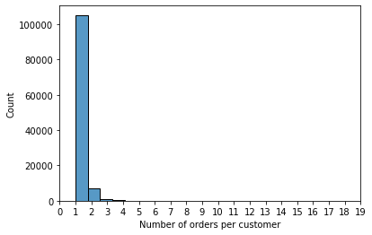

```python
plt.figure()
sns.histplot(data=df, x='total_number_of_orders')
plt.xlabel('Number of orders per customer')
plt.xticks(np.arange(0, 20, 1))
plt.show()
```

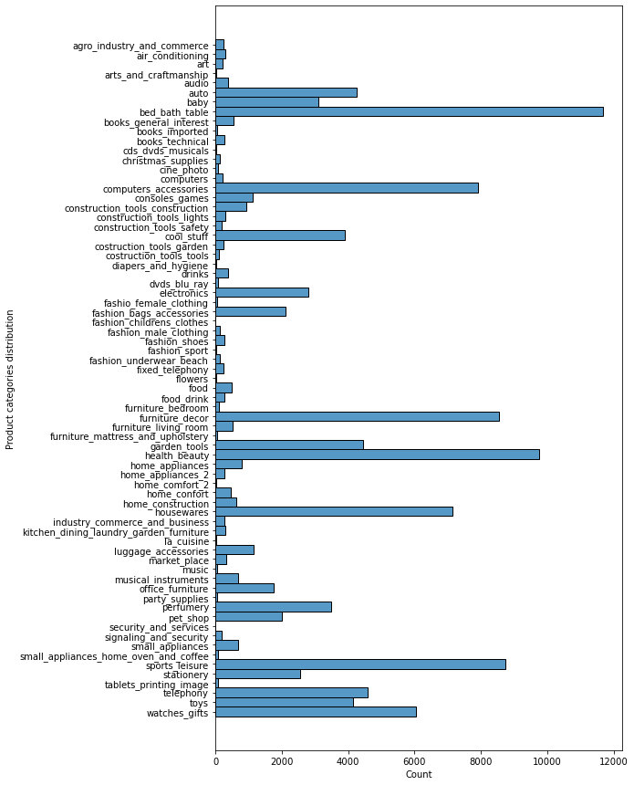

```python
plt.figure(figsize=(8, 15))
sns.histplot(data=df, y=df['product_category_name_english'].sort_values())
plt.ylabel('Product categories distribution')
plt.show()
```

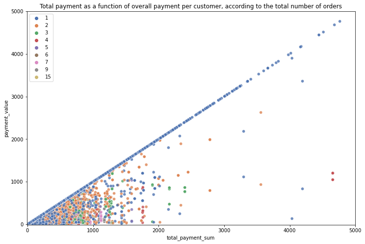

```python
plt.figure(figsize=(12, 8))
sns.scatterplot(data=df, x='total_payment_sum', y='payment_value',
                hue='total_number_of_orders', palette='deep',
                legend='full', alpha=0.8)
plt.xlim((-10, 5000))  # Focus on amounts < 5 000
plt.ylim((-10, 5000))  # Focus on amounts < 5 000
plt.legend(loc='best')
plt.title(
    'Total payment as a function of overall payment per customer,'
    ' according to the total number of orders')
plt.show()
```

```python
df.columns
```

```
Index(['customer_id', 'customer_unique_id', 'customer_zip_code_prefix',
       'customer_city', 'customer_state', 'order_id', 'order_status',
       'order_purchase_timestamp', 'order_approved_at',
       'order_delivered_carrier_date', 'order_delivered_customer_date',
       'order_estimated_delivery_date', 'total_number_of_orders', 'order_date',
       'days_since_order', 'payment_sequential', 'payment_type',
       'payment_installments', 'payment_value', 'total_payment_sum',
       'order_item_id', 'product_id', 'seller_id', 'shipping_limit_date',
       'price', 'freight_value', 'product_category_name',
       'product_category_name_english', 'product_name_lenght',
       'product_description_lenght', 'product_photos_qty', 'product_weight_g',
       'product_length_cm', 'product_height_cm', 'product_width_cm',
       'review_id', 'review_score', 'review_comment_title',
       'review_comment_message', 'review_creation_date',
       'review_answer_timestamp'],
      dtype='object')
```

```python
import missingno as msno
```

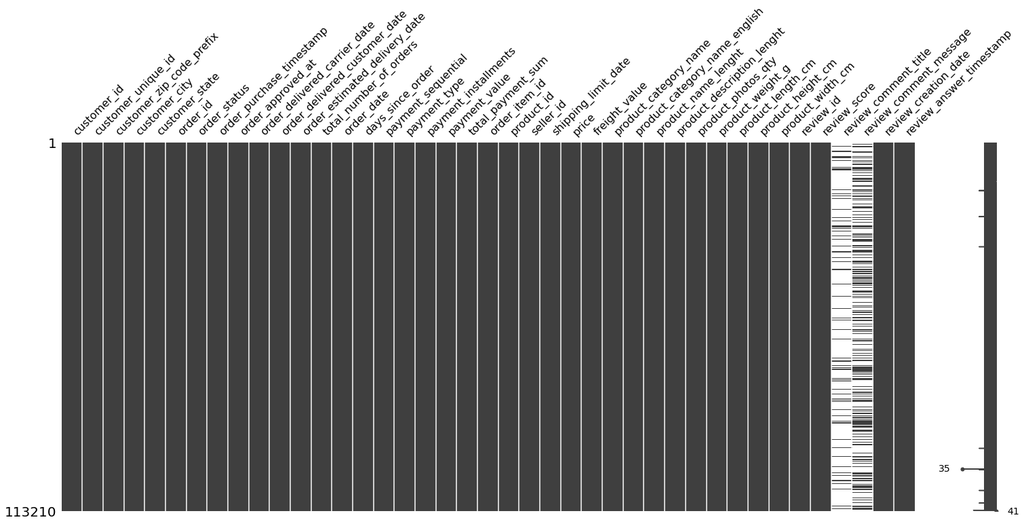

```python
msno.matrix(df)
```

```python
df.to_csv('data_for_clustering')
```